# week5Practice

M. Onimus

10/6/2020

# Read in Data

```r
week5 <- read_sav("practice/GLM_practice.sav")
```

# Question 1

Lou has completed a pilot study based on Caslake et al. (2008, Am. J.of Clin. Nutrition, 88(3): 618-629) to investigate the effects genotype on cardiovascular biomarker response to fish oils. Eighty African-American adults, aged 30–45 years, were prospectively recruited according to age, sex, and APOE genotype. Half of the participants were randomly assigned to ingest three 700 mg EPA+DHA/d (700FO) capsules per day for an 8-week intervention period. The other subjects consumed control oil capsules on the same regimen.

He is first interested in whether there is an association between subject age and HDL levels at baseline (HDL PRE).

## Question/Answer 1a

What is the correlation between age and baseline HDL?

```r
lm <- lm(HDL_PRE ~ age, data = week5)



#lm
```

## Question/Answer 1b

Write out the regression equation for the prediction of baseline HDL using subject age.

**$HDL = \beta_0 + \beta_1*age$**

## Question/Answer 1c

What are the null and alternative hypotheses for the test for an association between age and HDL, using your model?

**$H_0:\beta_1 = 0$** **$H_1:\beta_1\neq0$**

## Question/Answer 1d

What is the estimated regression equation? Also, provide a plot of it against a scatter plot of the data.

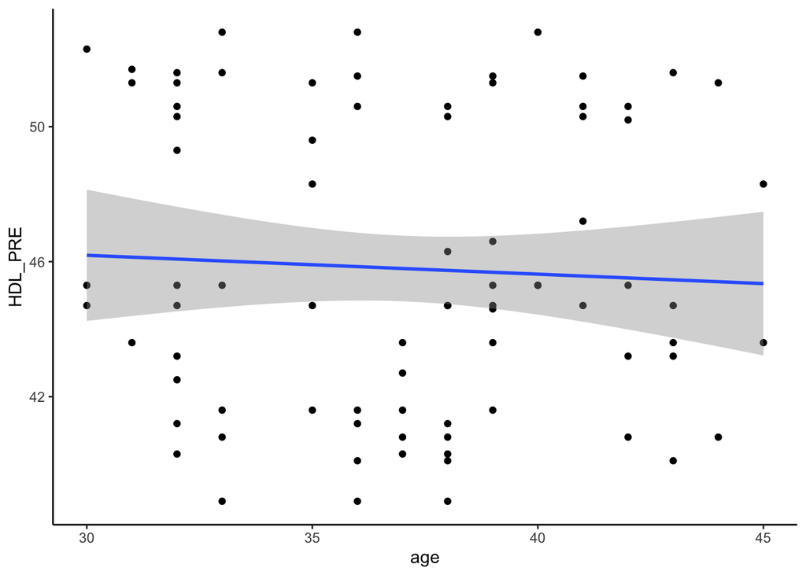

```r
ggplot(week5, aes(x = age, y = HDL_PRE)) +
  geom_point() +
  geom_smooth(method = 'lm') +
  theme_classic()
```

## Question/Answer 1e

What are the results of inference about the association (Parameter Estimate table)?

```r
summary(lm)
```

```
##
## Call:
## lm(formula = HDL_PRE ~ age, data = week5)
##
## Residuals:
##     Min      1Q  Median      3Q     Max
## -7.1211 -4.2112 -0.8812  4.7316  7.1706
##
## Coefficients:
##             Estimate Std. Error t value Pr(>|t|)
## (Intercept) 47.86753    4.46778  10.714   <2e-16 ***
## age         -0.05595    0.11982  -0.467    0.642
## ---
## Signif. codes:  0 '***' 0.001 '**' 0.01 '*' 0.05 '.' 0.1 ' ' 1
##
## Residual standard error: 4.374 on 78 degrees of freedom
## Multiple R-squared:  0.002788,   Adjusted R-squared:  -0.009997
## F-statistic: 0.2181 on 1 and 78 DF,  p-value: 0.6418
```

The results of interference indicate that the two parameters are not signifcantly associated with each other ($t_1=-0.467, p = 0.642$) at an $\alpha=0.05$ level.

## Question/Answer 1f

How do the assumptions of linear regression hold up in this case? Use the appropriate plots to support your discussion.

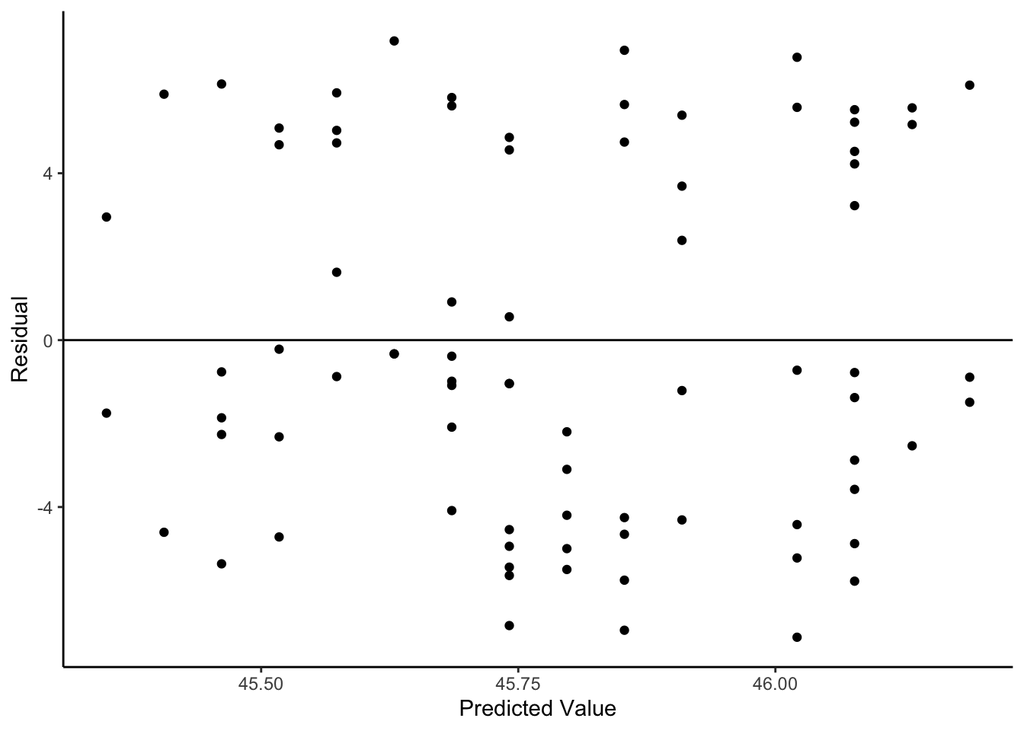

```r
ggplot(data = NULL, aes(x = lm$fitted.values, y = lm$residuals)) +
  geom_point() +
  geom_hline(yintercept = 0) +
  labs(
    x = "Predicted Value",
    y = "Residual"
  ) +
  theme_classic()
```

**The residual/predicted plot above shows a pretty equal distrubution of points above and below 0 although there may be less points below 0.**

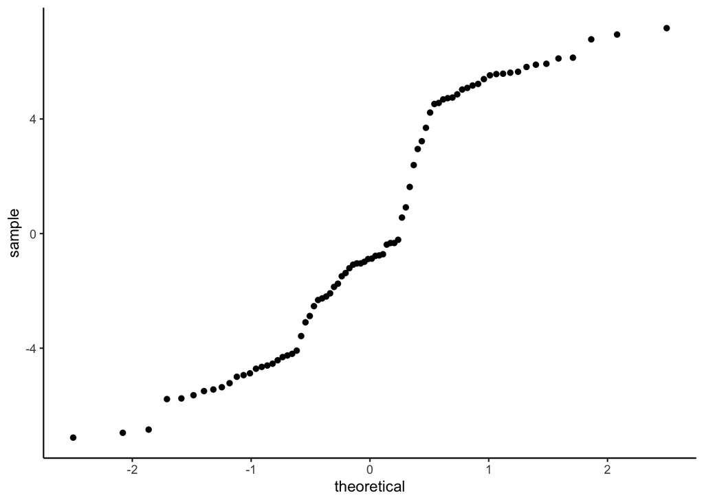

```r
ggplot(data = NULL, aes(sample = lm$residuals)) +
  geom_qq() +
  theme_classic()
```

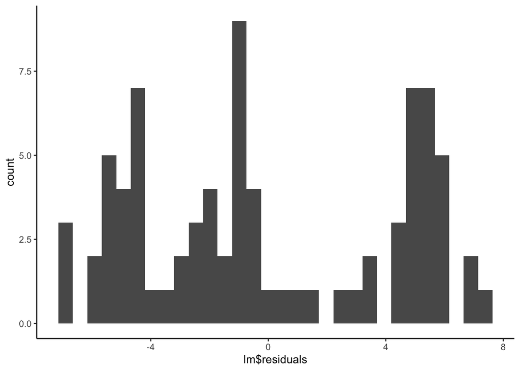

```r
ggplot(data = NULL, aes(x = lm$residuals)) +
  geom_histogram() +
  theme_classic()
```

**The qqplot and the histogram of residuals both show distrubtions which seem to not be normal. There is signifcant tailings at both ends of the qq plot and a number of modals present in the histogram.**

## Question/Answer 1g

Write a few sentences describing the results